# Lee Equity Center Weekly Updates

# June 21

This week I looked more closely at the LEAD and LODES data.

## LODES

Starting from where Michele left of on the "lodes_packages" script, I tried looking at differences in the proportion of high, mid, and low wage jobs in the different census tracts in Charlottesville.

```r
va_lodes_od <- read_lodes(state = "VA", type = "od", year = 2018,
                          segment = "main", job_type = "JT00")
```

```
## Cached version of file found in [/Users/Carlson/Desktop/Equity Center/summer-sandbox/lead-lodes/va_od_main_JT00_2018.csv.gz].
## Reading data from it...
```

To practice working with these data, I restricted the observations to just those in the Charlottesville census blocks.

```r
cviltracts <- c("51540000201", "51540000202", "51540000302", "51540000401", "51540000402", "51540000501", "51540000502", "51540000600",
                "51540000700", "51540000800", "51540000900","51540001000")

cvl_lodes <- va_lodes_od %>%
  mutate(w_county = str_sub(w_geocode, 1,11)) %>%
  filter(w_county %in% cviltracts)
```

Below I show the decsriptive statistics for the proportion of high, mid, and low wage jobs by each of the difference Charlottesville census blocks.

```r
wage <- cvl_lodes %>%
  group_by(w_county) %>%
  summarize(lowwage = sum(SE01),
            midwage = sum(SE02),
            hiwage = sum(SE03),
            allwage = sum(S000))

wage <- wage %>%
  group_by(w_county) %>%
  mutate(lowwage_p = lowwage/allwage,
         midwage_p = midwage/allwage,
         hiwage_p = hiwage/allwage)

describe(wage$hiwage_p)
```

```
##    vars  n mean   sd median trimmed  mad  min  max range skew kurtosis   se
## X1    1 12 0.37 0.14   0.36    0.36 0.14 0.18 0.65  0.47 0.37    -0.86 0.04
```

```r
describe(wage$lowwage_p)
```

```
##    vars  n mean   sd median trimmed  mad  min  max range skew kurtosis   se
## X1    1 12 0.28 0.14   0.25    0.28 0.14 0.07 0.51  0.43 0.31    -1.23 0.04
```

```r
describe(wage$midwage_p)
```

```
##    vars  n mean   sd median trimmed  mad  min  max range skew kurtosis   se
## X1    1 12 0.34 0.07   0.34    0.34 0.07 0.26 0.52  0.25 0.86    -0.06 0.02
```

To help simplify visualizing the data, I re-named each of the census tracts by my own rough naming of the neighborhoods/areas --- I'm sure better names exist (and I'm sure there's a more efficient way to do this than with a thousand ifelse statements)

```r
wage$area <- ifelse(wage$w_county == "51540000800", "Seminole Square",
                    ifelse(wage$w_county == "51540000700", "Barracks Shopping Center",
                           ifelse(wage$w_county == "51540000900", "Locust Grove",
                                  ifelse(wage$w_county == "51540000201", "Rose Hill",
                                         ifelse(wage$w_county == "51540000202", "10th and Page",
                                                ifelse(wage$w_county == "51540001000", "The Mall",
                                                       ifelse(wage$w_county == "51540000302", "Riverview",
                                                              ifelse(wage$w_county == "51540000600", "JPA",
                                                                     ifelse(wage$w_county == "51540000501", "Fifeville",
                                                                            ifelse(wage$w_county == "51540000502", "Fry's Spring",
                                                                                   ifelse(wage$w_county == "51540000401", "Belmont",
                                                                                          ifelse(wage$w_county == "51540000402","West View Terrace",wage$w_county))))))))))))

allwage <- ggplot(wage, aes(x = area, y = allwage)) +
  geom_bar(stat = 'identity', width = 0.5)+
  theme(axis.text.x = element_text(angle = 45, hjust = 1)) +
  labs(x = "Rough Area description", y = "Raw count of all jobs")
```

Here are the raw counts plotted together:

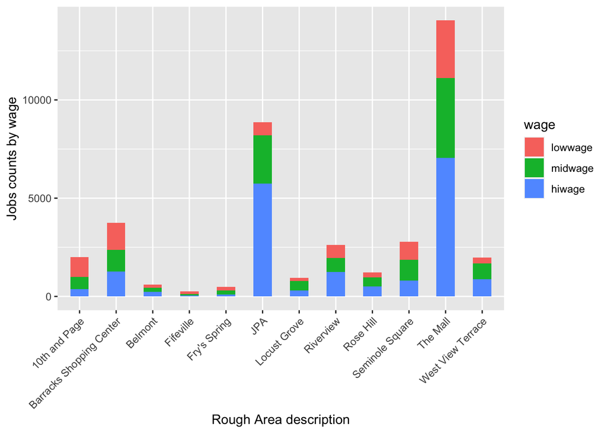

```r
wagelong <- melt(wage,
                 id.vars = c("w_county", "allwage", "area"),
                 measure.vars = c("lowwage", "midwage", "hiwage"),
                 variable.name = c("wage"),
                 value.name = "jobcount")

ggplot(wagelong, aes(x = area, y = jobcount, fill = wage))+
  geom_bar(stat = 'identity', width = 0.5) +
  theme(axis.text.x = element_text(angle = 45, hjust = 1)) +
  labs(x = "Rough Area description", y = "Jobs counts by wage")
```

Here are the proportions plotted together:

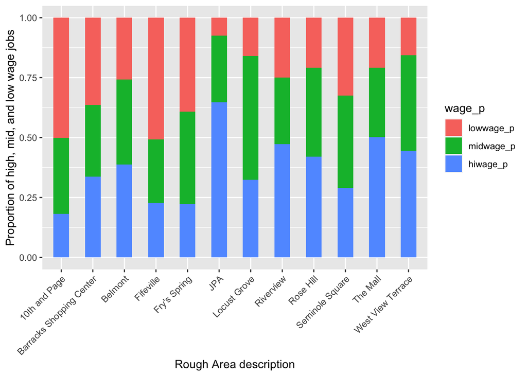

```r
wageplong <- melt(wage,
                 id.vars = c("w_county", "allwage", "area"),
                 measure.vars = c("lowwage_p", "midwage_p", "hiwage_p"),
                 variable.name = c("wage_p"),
                 value.name = "jobp")

ggplot(wageplong, aes(x = area, y = jobp, fill = wage_p))+
  geom_bar(stat = 'identity', width = 0.5) +
  theme(axis.text.x = element_text(angle = 45, hjust = 1))+
  labs(x = "Rough Area description", y = "Proportion of high, mid, and low wage jobs")
```

I repeated the process above but with racial demographics of the jobs, rather than wage.

```r
va_lodes_rac <- read_lodes(state = "VA", type = "residence", year = 2018,
                           segment = "S000", job_type = "JT00")
```

```
## Cached version of file found in [/Users/Carlson/Desktop/Equity Center/summer-sandbox/lead-lodes/va_rac_S000_JT00_2018.csv.gz].
## Reading data from it...
```

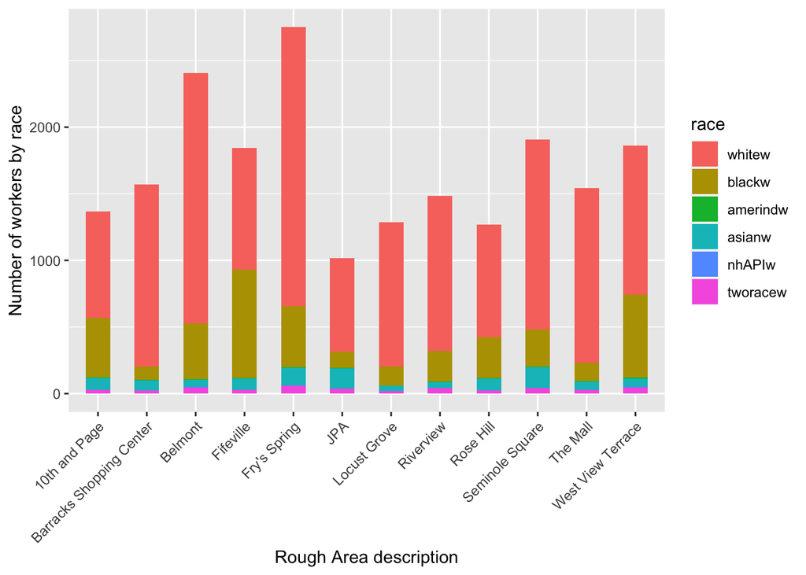

```r
cvl_rac <- va_lodes_rac %>%
  mutate(h_county = str_sub(h_geocode, 1,11)) %>%
  filter(h_county %in% cviltracts)

race <- cvl_rac %>%
  group_by(h_county) %>%
  summarize(whitew = sum(CR01),
            blackw = sum(CR02),
            amerindw = sum(CR03),
            asianw = sum(CR04),
            nhAPIw = sum(CR05),
            tworacew = sum(CR07),
            tot_w = sum(C000))

race$area <- ifelse(race$h_county == "51540000800", "Seminole Square",
                    ifelse(race$h_county == "51540000700", "Barracks Shopping Center",
                           ifelse(race$h_county == "51540000900", "Locust Grove",
                                  ifelse(race$h_county == "51540000201", "Rose Hill",
                                         ifelse(race$h_county == "51540000202", "10th and Page",
                                                ifelse(race$h_county == "51540001000", "The Mall",
                                                       ifelse(race$h_county == "51540000302", "Riverview",
                                                              ifelse(race$h_county == "51540000600", "JPA",
                                                                     ifelse(race$h_county == "51540000501", "Fifeville",
                                                                            ifelse(race$h_county == "51540000502", "Fry's Spring",
                                                                                   ifelse(race$h_county == "51540000402", "Belmont",
                                                                                          ifelse(race$h_county == "51540000401","West View Terrace", race$h_county))))))))))))

racelong <- melt(race,
                 id.vars = c("h_county", "area"),
                 measure.vars = c("whitew", "blackw", "amerindw", "asianw", "nhAPIw", "tworacew"),
                 variable.name = c("race"),
                 value.name = "jobcount")

ggplot(racelong, aes(x = area, y = jobcount, fill = race))+
  geom_bar(stat = 'identity', width = 0.5) +
  theme(axis.text.x = element_text(angle = 45, hjust = 1)) +
  labs(x = "Rough Area description", y = "Number of workers by race")
```

Looking at the proportion of workers in each racial group by each census tract:

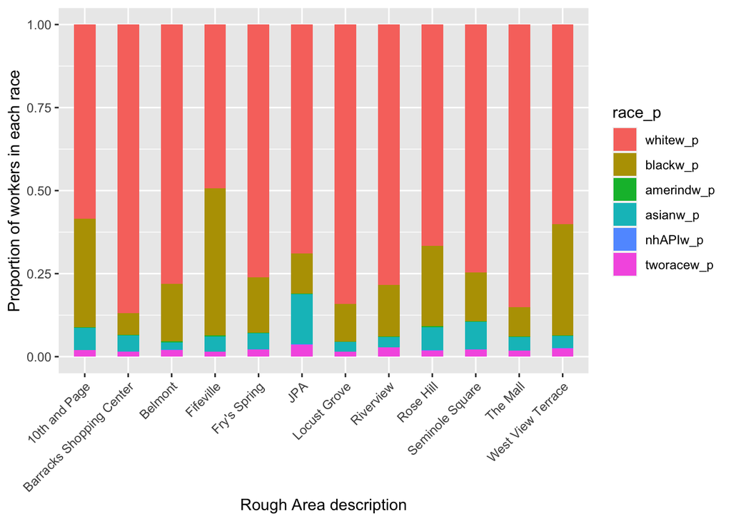

```r
race <- race %>%
  group_by(h_county) %>%
  mutate(whitew_p = whitew/tot_w,
         blackw_p = blackw/tot_w,
         amerindw_p = amerindw/tot_w,
         asianw_p = asianw/tot_w,
         nhAPIw_p = nhAPIw/tot_w,
         tworacew_p = tworacew/tot_w)

racelongp <- melt(race,
                 id.vars = c("h_county", "area"),
                 measure.vars = c("whitew_p", "blackw_p", "amerindw_p", "asianw_p", "nhAPIw_p", "tworacew_p"),
                 variable.name = c("race_p"),
                 value.name = "tot_w")

ggplot(racelongp, aes(x = area, y = tot_w, fill = race_p))+
  geom_bar(stat = 'identity', width = 0.5) +
  theme(axis.text.x = element_text(angle = 45, hjust = 1)) +
  labs(x = "Rough Area description", y = "Proportion of workers in each race")
```

### Questions I still have about the LODES data:

1. I don't quite understand the difference between the h_geocode and the w_geocode. Michele, you mentioned looking at differences between where workers live and work---I'm not sure how that information is represented in the data.
2. How interested are we in looking at changes over time? Data available for years 2002-2018.

### Next steps:

1. Figure out answers to the questions above.
2. Start trying to map the data. I plan to read more about how use Leaflet this week.

# June 14

I familiarized myself with the following datasources: Low-Income Energy Affordability Data (LEAD) Tool and Longitudinal Employer-Household Dynamics Origin-Destination Employment Statistics (LODES). The structure for each dataset is shown below. I also used [Jacob's handy-dandy function](https://github.com/jacob-gg/manager) to check for missing data! In instances where there were no missing data, I removed that line of code. Everything shown below is based on the csv's available for download from each of these sources---I've done no data cleaning or re-formatting.

```r
knitr::opts_chunk$set(echo = TRUE)
source('https://raw.githubusercontent.com/jacob-gg/manager/main/R/loch_missingness_monster.R')
setwd("/Users/Carlson/Desktop/Equity Center Data Exploration")
leaddat1 <- read.csv("VA AMI Census Tracts 2018.csv")
leaddat2 <- read.csv("VA FPL Census Tracts 2018.csv")
lodesOD <- read.csv("va_od_aux_JT00_2002.csv")
lodesRAC <- read.csv("va_rac_S000_JT00_2002.csv")
lodesWAC <- read.csv("va_wac_S000_JT00_2002.csv")
```

## LEAD

#### Abridged data dictionary:

- FIP: state, county, or city
- TEN: Owner or renter
- YBL6: Year of building construction
- BLD: Number of units in the building
- HFL INDEX: Primary heating fuel type
- AMI68: % Area Median Income
- FPL15: % Federal Poverty Level
- SMI68: % State Median Income
- HINCP: Avg. Annual household income ($/year)
- ELEP: Avg. household annnual electricity expenditure ($/year)
- GASP: Avg. household annual gas expenditure ($/year)
- FULP: Avg. household annual other fuel expenditure ($/year)

```r
str(leaddat1)
```

```
## 'data.frame':    1043210 obs. of  24 variables:
##  $ ABV          : chr  "VA" "VA" "VA" "VA" ...
##  $ FIP          : num  5.1e+10 5.1e+10 5.1e+10 5.1e+10 5.1e+10 ...
##  $ TEN          : chr  "OWNER" "OWNER" "OWNER" "OWNER" ...
##  $ YBL6         : chr  "1940-59" "1940-59" "1940-59" "1940-59" ...
##  $ BLD          : chr  "1 ATTACHED" "1 ATTACHED" "1 ATTACHED" "1 ATTACHED" ...
##  $ HFL          : chr  "BOTTLED GAS" "BOTTLED GAS" "BOTTLED GAS" "BOTTLED GAS" ...
##  $ AMI68        : chr  "0-30%" "100%+" "30-60%" "60-80%" ...
##  $ UNITS        : num  0.00 1.16e-10 3.92e-06 1.43e-12 0.00 ...
##  $ HINCP.UNITS  : num  0 0 0 0 0 0 0 0 0 0 ...
##  $ ELEP.UNITS   : num  0 0 0 0 0 0 0 0 0 0 ...
##  $ GASP.UNITS   : num  0 0 0 0 0 0 0 0 0 0 ...
##  $ FULP.UNITS   : num  0 0 0 0 0 0 0 0 0 0 ...
##  $ HINCP.UNITS.1: num  0 0 0 0 0 0 0 0 0 0 ...
##  $ ELEP.UNITS.1 : num  0 0 0 0 0 0 0 0 0 0 ...
##  $ GASP.UNITS.1 : num  0 0 0 0 0 0 0 0 0 0 ...
##  $ FULP.UNITS.1 : num  0 0 0 0 0 0 0 0 0 0 ...
##  $ HCOUNT       : num  NA NA NA NA NA NA NA NA NA NA ...
##  $ ECOUNT       : num  NA NA NA NA NA NA NA NA NA NA ...
##  $ GCOUNT       : num  NA NA NA NA NA NA NA NA NA NA ...
##  $ FCOUNT       : num  NA NA NA NA NA NA NA NA NA NA ...
##  $ HINCP        : num  NA NA NA NA NA NA NA NA NA NA ...
##  $ ELEP         : num  NA NA NA NA NA NA NA NA NA NA ...
##  $ GASP         : num  NA NA NA NA NA NA NA NA NA NA ...
##  $ FULP         : num  NA NA NA NA NA NA NA NA NA NA ...
```

```r
loch_missingness_monster(leaddat1)
```

```
## There are 4492663 missing values in the dataset
## The maximum number of values that any variable is missing is 587934
##
## Number of missing values per variable:
##  ABV FIP TEN YBL6 BLD HFL AMI68 UNITS HINCP.UNITS ELEP.UNITS GASP.UNITS
##    0   0   0    0   0   0     0     0           0          0          0
##  FULP.UNITS HINCP.UNITS.1 ELEP.UNITS.1 GASP.UNITS.1 FULP.UNITS.1 HCOUNT ECOUNT
##           0             0            0            0            0 533839 547763
##  GCOUNT FCOUNT  HINCP   ELEP   GASP   FULP
##  537159 550640 574350 585656 587934 575322
```

```r
str(leaddat2)
```

```
## 'data.frame':    1043210 obs. of  24 variables:
##  $ ABV          : chr  "VA" "VA" "VA" "VA" ...
##  $ FIP          : num  5.1e+10 5.1e+10 5.1e+10 5.1e+10 5.1e+10 ...
##  $ TEN          : chr  "OWNER" "OWNER" "OWNER" "OWNER" ...
##  $ YBL6         : chr  "1940-59" "1940-59" "1940-59" "1940-59" ...
##  $ BLD          : chr  "1 ATTACHED" "1 ATTACHED" "1 ATTACHED" "1 ATTACHED" ...
##  $ HFL          : chr  "BOTTLED GAS" "BOTTLED GAS" "BOTTLED GAS" "BOTTLED GAS" ...
##  $ FPL15        : chr  "0-100%" "100-150%" "150-200%" "200-400%" ...
##  $ UNITS        : num  0.00 3.67e-06 2.46e-07 3.65e-13 1.16e-10 ...
##  $ HINCP.UNITS  : num  0 0 0 0 0 0 0 0 0 0 ...
##  $ ELEP.UNITS   : num  0 0 0 0 0 0 0 0 0 0 ...
##  $ GASP.UNITS   : num  0 0 0 0 0 0 0 0 0 0 ...
##  $ FULP.UNITS   : num  0 0 0 0 0 0 0 0 0 0 ...
##  $ HINCP.UNITS.1: num  0 0 0 0 0 0 0 0 0 0 ...
##  $ ELEP.UNITS.1 : num  0 0 0 0 0 0 0 0 0 0 ...
##  $ GASP.UNITS.1 : num  0 0 0 0 0 0 0 0 0 0 ...
##  $ FULP.UNITS.1 : num  0 0 0 0 0 0 0 0 0 0 ...
##  $ HCOUNT       : num  NA NA NA NA NA NA NA NA NA NA ...
##  $ ECOUNT       : num  NA NA NA NA NA NA NA NA NA NA ...
##  $ GCOUNT       : num  NA NA NA NA NA NA NA NA NA NA ...
##  $ FCOUNT       : num  NA NA NA NA NA NA NA NA NA NA ...
##  $ HINCP        : num  NA NA NA NA NA NA NA NA NA NA ...
##  $ ELEP         : num  NA NA NA NA NA NA NA NA NA NA ...
##  $ GASP         : num  NA NA NA NA NA NA NA NA NA NA ...
##  $ FULP         : num  NA NA NA NA NA NA NA NA NA NA ...
```

```r
loch_missingness_monster(leaddat2)
```

```
## There are 4733887 missing values in the dataset
## The maximum number of values that any variable is missing is 620246
##
## Number of missing values per variable:
##  ABV FIP TEN YBL6 BLD HFL FPL15 UNITS HINCP.UNITS ELEP.UNITS GASP.UNITS
##    0   0   0    0   0   0     0     0           0          0          0
##  FULP.UNITS HINCP.UNITS.1 ELEP.UNITS.1 GASP.UNITS.1 FULP.UNITS.1 HCOUNT ECOUNT
##           0             0            0            0            0 561443 575178
##  GCOUNT FCOUNT  HINCP   ELEP   GASP   FULP
##  564679 578007 607858 618157 620246 608319
```

## LODES

Per the website, "Data files are state-based and organized into three types: Origin-Destination (OD), Residence Area Characteristics (RAC), and Workplace Area Characteristics (WAC), all at census block geographic detail. Data is available for most states for the years 2002–2018." There are two versions of each of these---one using 2000 census blocks and one using 2010 census blocks. Below, I show the structures and missing data information for the 2010 versions for each dataset---OD ("lodesOD), RAC ("lodesRAC""), and WAC ("lodesRAC").

### Origin-Destination (OD)

#### Abridged data dictionary:

- S000: Total # of jobs
- SA01--SA03: # of jobs for different age groups
- SE01--SE03: # of jobs with different earnings per month
- S101--S103: # of jobs in different industries

```r
str(lodesOD)
```

```
## 'data.frame':    200210 obs. of  13 variables:
##  $ w_geocode : num  5.1e+14 5.1e+14 5.1e+14 5.1e+14 5.1e+14 ...
##  $ h_geocode : num  4.20e+14 4.51e+14 4.51e+14 1.00e+14 2.40e+14 ...
##  $ S000      : int  1 1 1 1 1 1 1 1 1 1 ...
##  $ SA01      : int  0 0 1 0 0 1 1 0 0 0 ...
##  $ SA02      : int  1 1 0 1 1 0 0 1 0 1 ...
##  $ SA03      : int  0 0 0 0 0 0 0 0 1 0 ...
##  $ SE01      : int  1 1 0 1 1 1 1 0 0 0 ...
##  $ SE02      : int  0 0 1 0 0 0 0 1 1 1 ...
##  $ SE03      : int  0 0 0 0 0 0 0 0 0 0 ...
##  $ SI01      : int  1 0 0 0 0 0 0 0 0 0 ...
##  $ SI02      : int  0 1 1 0 0 0 1 1 0 0 ...
##  $ SI03      : int  0 0 0 1 1 1 0 0 1 1 ...
##  $ createdate: int  20160228 20160228 20160228 20160228 20160228 20160228 20160228 20160228 20160228 20160228 ...
```

### Residence Area Characteristics (RAC)

#### Abridged data dictionary:

- C000: Total # of jobs
- CA01--CA03: # of jobs for different age groups
- CE01--CE03: # of jobs with different earnings per month
- CNS01--CNS20: # of jobs in different NAICS sectors
- CR01--CR07: # of jobs for workers with different races
- CT01--CT02: # of jobs for Hispanic and non-Hispanic workers
- CD01--CD04: # of jobs by educational attainment
- CS01--CS02: # of jobs by sex

```r
str(lodesRAC[,1:10])
```

```
## 'data.frame':    146780 obs. of  10 variables:
##  $ h_geocode: num  5.1e+14 5.1e+14 5.1e+14 5.1e+14 5.1e+14 ...
##  $ C000     : int  3 1 3 37 6 2 5 1 16 25 ...
##  $ CA01     : int  1 0 0 8 3 0 0 1 2 9 ...
##  $ CA02     : int  1 0 2 23 3 2 5 0 11 7 ...
##  $ CA03     : int  1 1 1 6 0 0 0 0 3 9 ...
##  $ CE01     : int  2 0 1 19 3 1 2 1 7 10 ...
##  $ CE02     : int  1 0 2 15 2 1 2 0 8 14 ...
##  $ CE03     : int  0 1 0 3 1 0 1 0 1 1 ...
##  $ CNS01    : int  0 0 0 0 0 0 0 0 1 0 ...
##  $ CNS02    : int  0 0 0 0 0 0 0 0 0 0 ...
```

### Workplace Area Characteristics (WAC)

#### Abridged data dictionary:

- First 42 columns: All of the same data as the RAC datafile
- CFA01--CFA05: # of jobs by firm age
- CFS01--CFS05: # of jobs by firm size

```r
str(lodesWAC[,1:10])
```

```
## 'data.frame':    69594 obs. of  10 variables:
##  $ w_geocode: num  5.1e+14 5.1e+14 5.1e+14 5.1e+14 5.1e+14 ...
##  $ C000     : int  1 8 8 17 4 1 44 25 52 2 ...
##  $ CA01     : int  0 2 0 8 0 0 9 6 5 0 ...
##  $ CA02     : int  0 4 6 9 3 1 29 16 35 2 ...
##  $ CA03     : int  1 2 2 0 1 0 6 3 12 0 ...
##  $ CE01     : int  1 6 2 11 2 0 23 14 45 2 ...
##  $ CE02     : int  0 1 2 6 2 1 21 11 6 0 ...
##  $ CE03     : int  0 1 4 0 0 0 0 0 1 0 ...
##  $ CNS01    : int  0 0 0 0 0 0 0 0 0 0 ...
##  $ CNS02    : int  0 0 0 0 0 0 0 0 0 0 ...
```

#### And, I learned that you can embed gifs in R Markdown! Huzzah!

[figure not shown]